# Monthly_EDA

```python
import numpy as np
import pandas as pd
import matplotlib.pyplot as plt
import seaborn as sns

%matplotlib inline
```

```python
abengers_df=pd.read_csv('./archive/charcters_stats.csv')
abengers_df.head()
```

|  | Name | Alignment | Intelligence | Strength | Speed | Durability | Power | Combat | Total |
| --- | --- | --- | --- | --- | --- | --- | --- | --- | --- |
| 0 | 3-D Man | good | 50 | 31 | 43 | 32 | 25 | 52 | 233 |
| 1 | A-Bomb | good | 38 | 100 | 17 | 80 | 17 | 64 | 316 |
| 2 | Abe Sapien | good | 88 | 14 | 35 | 42 | 35 | 85 | 299 |
| 3 | Abin Sur | good | 50 | 90 | 53 | 64 | 84 | 65 | 406 |
| 4 | Abomination | bad | 63 | 80 | 53 | 90 | 55 | 95 | 436 |

```python
abengers_total=abengers_df.sort_values(by=['Total'], axis=0,ascending=False).head(10)
abengers_total
```

|  | Name | Alignment | Intelligence | Strength | Speed | Durability | Power | Combat | Total |
| --- | --- | --- | --- | --- | --- | --- | --- | --- | --- |
| 361 | Martian Manhunter | good | 100 | 100 | 96 | 100 | 100 | 85 | 581 |
| 242 | General Zod | bad | 94 | 100 | 96 | 100 | 94 | 95 | 579 |
| 535 | Superboy-Prime | bad | 94 | 100 | 100 | 100 | 100 | 85 | 579 |
| 537 | Superman | good | 100 | 100 | 100 | 100 | 94 | 85 | 579 |
| 16 | Amazo | bad | 75 | 100 | 100 | 100 | 100 | 100 | 575 |
| 525 | Stardust | good | 88 | 85 | 100 | 110 | 100 | 85 | 568 |
| 238 | Galactus | neutral | 100 | 100 | 83 | 100 | 100 | 70 | 553 |
| 82 | Bizarro | neutral | 75 | 95 | 100 | 100 | 95 | 85 | 550 |
| 203 | Dormammu | bad | 88 | 95 | 83 | 100 | 100 | 80 | 546 |
| 546 | Thor | good | 69 | 100 | 92 | 100 | 100 | 85 | 546 |

# top 20의 total status

[figure not shown]

```python
abengers_total=abengers_df.sort_values(by=['Total'], axis=0).tail(20)#,ascending=False
plt.figure(figsize=(15,10))
g=sns.barplot(x="Total", y="Name", data=abengers_total,alpha=0.8, palette='Reds')
ax=g
for p in ax.patches:
    left, bottom, width, height = p.get_bbox().bounds
    ax.annotate("%.0f"%(width), (width*1.02,bottom+height/2),ha='center')

plt.xlabel('Total staus')
plt.show()
```

```python
from math import pi
from matplotlib.path import Path
from matplotlib.spines import Spine
from matplotlib.transforms import Affine2D
```

# top 5 의 status

[figure not shown]

```python
abengers_total_top5=abengers_df.sort_values(by=['Total'], axis=0).tail(5)#,ascending=False
abengers_total_top5=abengers_total_top5.reset_index(drop=True)

labels = abengers_total_top5.columns[2:-1]
num_labels = len(labels)


angles = [x/float(num_labels)*(2*pi) for x in range(num_labels)] ## 각 등분점
angles += angles[:1] ## 시작점으로 다시 돌아와야하므로 시작점 추가

my_palette = plt.cm.get_cmap("Set2", len(abengers_total_top5.index))

fig = plt.figure(figsize=(15,20))
fig.set_facecolor('white')

for i, row in abengers_total_top5.iterrows():
    color = my_palette(i)
    #data = abengers_total.iloc[i].drop(['Name','Alignment','Total']).tolist()
    data = abengers_total_top5.iloc[i].drop(['Name','Alignment','Total']).tolist()
    data += data[:1]


    ax = plt.subplot(3,2,i+1, polar=True)
    ax.set_theta_offset(pi / 2) ## 시작점
    ax.set_theta_direction(-1) ## 그려지는 방향 시계방향

    plt.xticks(angles[:-1], labels, fontsize=13) ## x축 눈금 라벨
    ax.tick_params(axis='x', which='major', pad=15) ## x축과 눈금 사이에 여백을 준다.

    ax.set_rlabel_position(0) ## y축 각도 설정(degree 단위)
    plt.yticks([0,20,40,60,80,100],['0','20','40','60','80','100'], fontsize=10) ## y축 눈금 설정
    plt.ylim(0,100)

    ax.plot(angles, data, color=color, linewidth=2, linestyle='solid') ## 레이더 차트 출력
    ax.fill(angles, data, color=color, alpha=0.4) ## 도형 안쪽에 색을 채워준다.


    plt.title(row.Name, size=20, color=color,x=-0.2, y=1, ha='left') ## 타이틀은 캐릭터 클래스로 한다.
```

# Under 5의 status를 알아볼까

- Under의 능력치가 10단위 이하라 단위도 10으로 설정....

```python
abengers_total_under5=abengers_df.sort_values(by=['Total'], axis=0).head(5)#,ascending=False
abengers_total_under5=abengers_total_under5.reset_index(drop=True)
abengers_total_under5
```

|  | Name | Alignment | Intelligence | Strength | Speed | Durability | Power | Combat | Total |
| --- | --- | --- | --- | --- | --- | --- | --- | --- | --- |
| 0 | Cerebra | good | 1 | 1 | 1 | 1 | 0 | 1 | 5 |
| 1 | Cheetah II | bad | 1 | 1 | 1 | 1 | 0 | 1 | 5 |
| 2 | Cheetah III | bad | 1 | 1 | 1 | 1 | 0 | 1 | 5 |
| 3 | Chromos | bad | 1 | 1 | 1 | 1 | 0 | 1 | 5 |
| 4 | Clea | good | 1 | 1 | 1 | 1 | 0 | 1 | 5 |

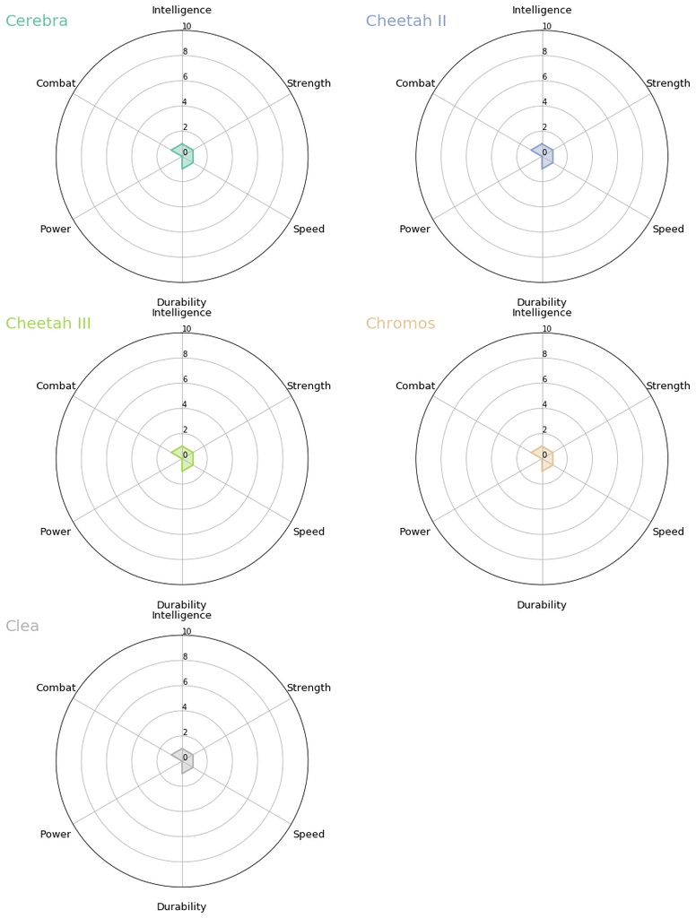

```python
abengers_total_under5=abengers_df.sort_values(by=['Total'], axis=0).head(5)#,ascending=False
abengers_total_under5=abengers_total_under5.reset_index(drop=True)

labels = abengers_total_under5.columns[2:-1]
num_labels = len(labels)


angles = [x/float(num_labels)*(2*pi) for x in range(num_labels)] ## 각 등분점
angles += angles[:1] ## 시작점으로 다시 돌아와야하므로 시작점 추가

my_palette = plt.cm.get_cmap("Set2", len(abengers_total_under5.index))

fig = plt.figure(figsize=(15,20))
fig.set_facecolor('white')

for i, row in abengers_total_under5.iterrows():
    color = my_palette(i)
    data = abengers_total_under5.iloc[i].drop(['Name','Alignment','Total']).tolist()
    data += data[:1]


    ax = plt.subplot(3,2,i+1, polar=True)
    ax.set_theta_offset(pi / 2) ## 시작점
    ax.set_theta_direction(-1) ## 그려지는 방향 시계방향

    plt.xticks(angles[:-1], labels, fontsize=13) ## x축 눈금 라벨
    ax.tick_params(axis='x', which='major', pad=15) ## x축과 눈금 사이에 여백을 준다.

    ax.set_rlabel_position(0) ## y축 각도 설정(degree 단위)
    plt.yticks([0,2,4,6,8,10],['0','2','4','6','8','10'], fontsize=10) ## y축 눈금 설정
    plt.ylim(0,10)

    ax.plot(angles, data, color=color, linewidth=2, linestyle='solid') ## 레이더 차트 출력
    ax.fill(angles, data, color=color, alpha=0.4) ## 도형 안쪽에 색을 채워준다.


    plt.title(row.Name, size=20, color=color,x=-0.2, y=1, ha='left') ## 타이틀은 캐릭터 클래스로 한다.
```

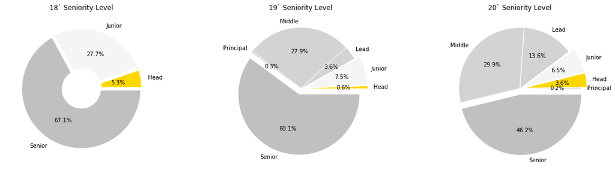

```python
import numpy as np
import pandas as pd
import matplotlib.pyplot as plt
import seaborn as sns


%matplotlib inline



salary_1819=pd.read_csv('./salary_201819.csv')
salary_18=pd.read_csv('./IT Salary Survey EU 2018.csv')
salary_19=pd.read_csv('./IT Salary Survey EU 2019.csv')
salary_20=pd.read_csv('./IT Salary Survey EU  2020.csv')


plt.figure(figsize=(20,5))
salary_18_by_level=salary_18.groupby(['Your level']).count()
ratio=salary_18_by_level['Current Salary']
labels = ['Head', 'Junior', 'Senior']
explode = [0.01, 0.01, 0.01]
colors = ['gold', 'whitesmoke', 'silver']
wedgeprops={'width': 0.7, 'edgecolor': 'w', 'linewidth': 5}
plt.subplot(131)
plt.pie(ratio, labels=labels, autopct='%.1f%%',explode=explode,colors=colors, wedgeprops=wedgeprops)
title='18` Seniority Level'
plt.title(title)



salary_19_by_level=salary_19.groupby(['Seniority level']).count()
ratio = salary_19_by_level['Zeitstempel']
labels = ['Head', 'Junior', 'Lead', 'Middle','Principal','Senior']
explode = [0.1,0.1,0.01,0.01,0.01,0.1]
colors = ['gold', 'whitesmoke', 'lightgray', 'lightgray','lightgray','silver']
#wedgeprops={'width': 0.7, 'edgecolor': 'w', 'linewidth': 5}
plt.subplot(132)
plt.pie(ratio, labels=labels, autopct='%.1f%%',explode=explode,colors=colors)#, wedgeprops=wedgeprops
title='19` Seniority Level'
plt.title(title)



salary_20_by_level=salary_20.groupby(['Seniority level']).count()
ratio=salary_20_by_level.sort_values(by=['Timestamp'],axis=0).tail(6)['Timestamp']
labels = ['Principal', 'Head', 'Junior', 'Lead','Middle','Senior']
explode = [0.01,0.1,0.1,0.01,0.01,0.1]
colors = ['lightgray', 'gold', 'whitesmoke', 'lightgray','lightgray','silver']
#wedgeprops={'width': 0.7, 'edgecolor': 'w', 'linewidth': 5}
plt.subplot(133)
plt.pie(ratio, labels=labels, autopct='%.1f%%',explode=explode,colors=colors)#, wedgeprops=wedgeprops
title='20` Seniority Level'
plt.title(title)
plt.show()
```

### 남, 여 나이대 분포

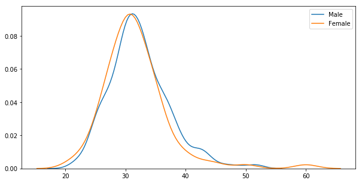

```python
fig, ax =plt.subplots(1,1,figsize=(10,5))

sns.kdeplot(data=salary_1819[salary_1819.Gender=='M']['Age'], ax=ax) #kdeplot을 어떤 축에 그릴거야. 난 위의 ax에 그릴거야
sns.kdeplot(data=salary_1819[salary_1819.Gender=='F']['Age'],ax=ax)
plt.legend(["Male","Female"])
plt.show()
```

### 2. [Kaggle](https://www.kaggle.com/datasets)에서 Dataset을 찾고, 이 Dataset에서 유의미한 Feature를 3개 이상 찾고 이를 시각화해봅시다.

함께 보면 좋은 라이브러리 document

- numpy
- pandas
- seaborn
- matplotlib

```python
heart_disease_df=pd.read_csv('./healthcare-dataset-stroke-data.csv')
heart_disease_df.head()
```

|  | id | gender | age | hypertension | heart_disease | ever_married | work_type | Residence_type | avg_glucose_level | bmi | smoking_status | stroke |
| --- | --- | --- | --- | --- | --- | --- | --- | --- | --- | --- | --- | --- |
| 0 | 9046 | Male | 67.0 | 0 | 1 | Yes | Private | Urban | 228.69 | 36.6 | formerly smoked | 1 |
| 1 | 51676 | Female | 61.0 | 0 | 0 | Yes | Self-employed | Rural | 202.21 | NaN | never smoked | 1 |
| 2 | 31112 | Male | 80.0 | 0 | 1 | Yes | Private | Rural | 105.92 | 32.5 | never smoked | 1 |
| 3 | 60182 | Female | 49.0 | 0 | 0 | Yes | Private | Urban | 171.23 | 34.4 | smokes | 1 |
| 4 | 1665 | Female | 79.0 | 1 | 0 | Yes | Self-employed | Rural | 174.12 | 24.0 | never smoked | 1 |

```python
heart_disease_df.corr()
```

|  | id | age | hypertension | heart_disease | avg_glucose_level | bmi | stroke |
| --- | --- | --- | --- | --- | --- | --- | --- |
| id | 1.000000 | 0.003538 | 0.003550 | -0.001296 | 0.001092 | 0.003084 | 0.006388 |
| age | 0.003538 | 1.000000 | 0.276398 | 0.263796 | 0.238171 | 0.333398 | 0.245257 |
| hypertension | 0.003550 | 0.276398 | 1.000000 | 0.108306 | 0.174474 | 0.167811 | 0.127904 |
| heart_disease | -0.001296 | 0.263796 | 0.108306 | 1.000000 | 0.161857 | 0.041357 | 0.134914 |
| avg_glucose_level | 0.001092 | 0.238171 | 0.174474 | 0.161857 | 1.000000 | 0.175502 | 0.131945 |
| bmi | 0.003084 | 0.333398 | 0.167811 | 0.041357 | 0.175502 | 1.000000 | 0.042374 |
| stroke | 0.006388 | 0.245257 | 0.127904 | 0.134914 | 0.131945 | 0.042374 | 1.000000 |

### 1. 혈중 평균 포도당 수준이 높으면 심장병이 있을까?

- 인과 x, 상관 o
- 대체적으로 평균 포도당 수치가 약 125이상부터 심장병 질환과 상관있어 보인다.

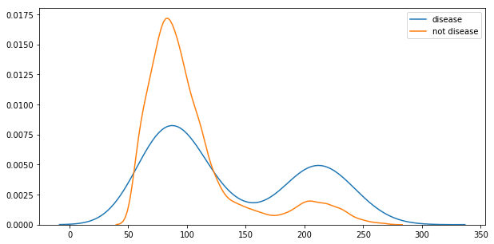

```python
fig, ax =plt.subplots(1,1,figsize=(10,5))
sns.kdeplot(data=heart_disease_df[heart_disease_df.heart_disease==1]['avg_glucose_level'],ax=ax)
sns.kdeplot(data=heart_disease_df[heart_disease_df.heart_disease==0]['avg_glucose_level'],ax=ax)
plt.legend(["disease","not disease"])
plt.show()
```

### 2. 거주 유형과 심장병과는 상관이 있을까?

- 도심이나 농촌이나 심장병에 걸린 사람수는 같음

```python
heart_disease_df.groupby(['heart_disease','Residence_type']).count()

heart_disease_df.groupby(['heart_disease','Residence_type'])['heart_disease'].count()
```

```
heart_disease  Residence_type
0              Rural             2380
               Urban             2454
1              Rural              134
               Urban              142
Name: heart_disease, dtype: int64
```

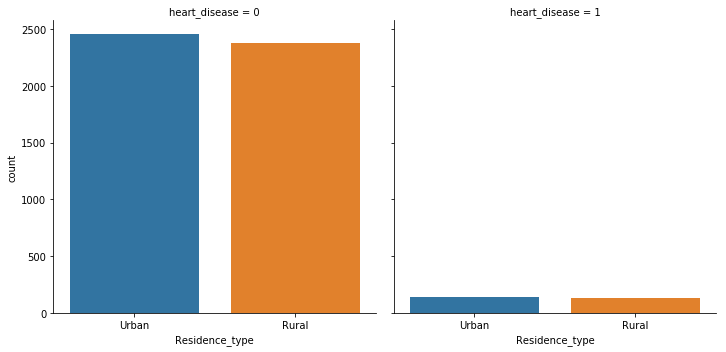

```python
sns.catplot(x='Residence_type', col='heart_disease', kind='count',data=heart_disease_df)
plt.show()
```

### 3. 심장병은 성별과 나이에 따라 다를까?

- 그래프로 봤을 때, 심장병은 40대 이후로 급격하게 증가하는 양상을 보임
- 남,여 모두 40~80세까지 심장병 걸릴 확률이 높고 그 이후 급격히 하락(80세 이후의 표본이 적을 것이라 판단)
- 약 45~75세까지 여성보다 남성이 심장병 걸린 비율이 높으며 75세부터는 여성의 심장병 비율이 남성보다 높음

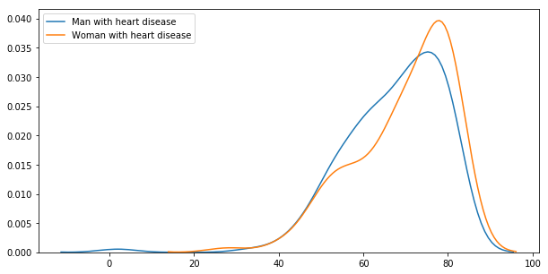

```python
fig, ax =plt.subplots(1,1,figsize=(10,5))

heart_disease_1=heart_disease_df[heart_disease_df.heart_disease==1]
heart_disease_1_M=heart_disease_1[heart_disease_1.gender=='Male']['age']
heart_disease_1_F=heart_disease_1[heart_disease_1.gender=='Female']['age']
sns.kdeplot(data=heart_disease_1_M,ax=ax)
sns.kdeplot(data=heart_disease_1_F,ax=ax)
plt.legend(["Man with heart disease","Woman with heart disease"])
plt.show()
```

### 4. 심장병과 흡연상태는?

- 전체적으로 흡연을 했던 사람과 흡연을 하고 있는 사람의 심장병 발생 비가 높은 것으로 확인
- 모든 면에서 남성이 여성보다 높고, 남과 여 모두 흡연상태의 모양은 같다.
- 흡연과 심장병과 상관있을 가능성이 크다

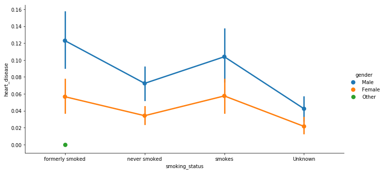

```python
sns.catplot(x='smoking_status',y='heart_disease', hue='gender',kind='point',data=heart_disease_df, height  = 5 , aspect =2)
plt.show()
```